# Quick pepFunk report

Suggestions to imetalabca@gmail.com

Report generated @2021-04-29 13:59:21

# Introduction to peptide-centric data analysis

This report is completely based on **peptide** intensity values. The functional enrichment information is also peptide-centric as identified by pepFunk.

**To note**: Currently, functional enrichment by pepFunk is specific to the **human gut microbiome** because it uses a curated peptide database. PCA and hierarchical clustering uses all identified peptides and is appropriate for any sample type. However, the enrichment results will only be accurate from human gut microbiome data. *If you’d like to use pepFunk for another system with your own peptide-centric functional database, please see the [Shiny app](https://shiny2.imetalab.ca/shiny/rstudio/pepFunk/)*.

In this report you will find:

- A principal component analysis (PCA) biplot visualizing PC1 and PC2, the two components that explain the most variation in your dataset.
- A hierarchical clustering dendrogram visualizing the relationships between samples as explained by peptide intensity similarity.
- Various pepFunk heatmaps describing the molecular functional profiles of your human gut microbiome sample.

# Principal Component Analysis (PCA)

PCA is a data exploration technique that can be used for quality control and pattern discovery.

In this case, our report visualizes PC1 vs PC2. These are the two components that explain the most variation in this dataset (13.83% and 11.25% respectively).

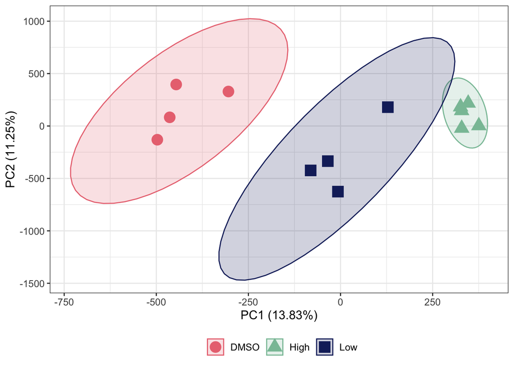

# Hierachical clustering

Hierarchical clustering can also be used to visualize sample similarities.

In this default plot we are using `euclidian` distance and the `complete` agglomeration hierachical clustering method.

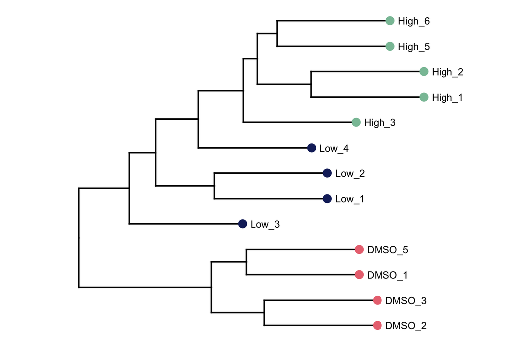

# Functional enrichment analysis

## KEGG pathways

There were **90 KEGG pathway peptide sets** identified in your data (with a minimum of 10 peptides per set).

The following table describes the number of significantly enriched KEGG pathways in your dataset:

The number of significantly enriched KEGG pathways when compared to reference condition.

[output not shown]

### A simple **heatmap** describing significantly different KEGG pathways when compared to a reference condition

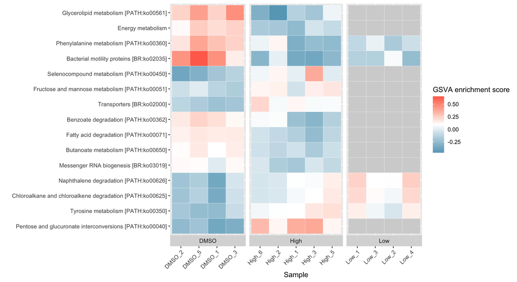

## All pathways

Although less informative, all identified peptide gene sets and their accompanying GSVA scores are plotted below.

### A simple **heatmap** describing all KEGG pathways identified in the dataset

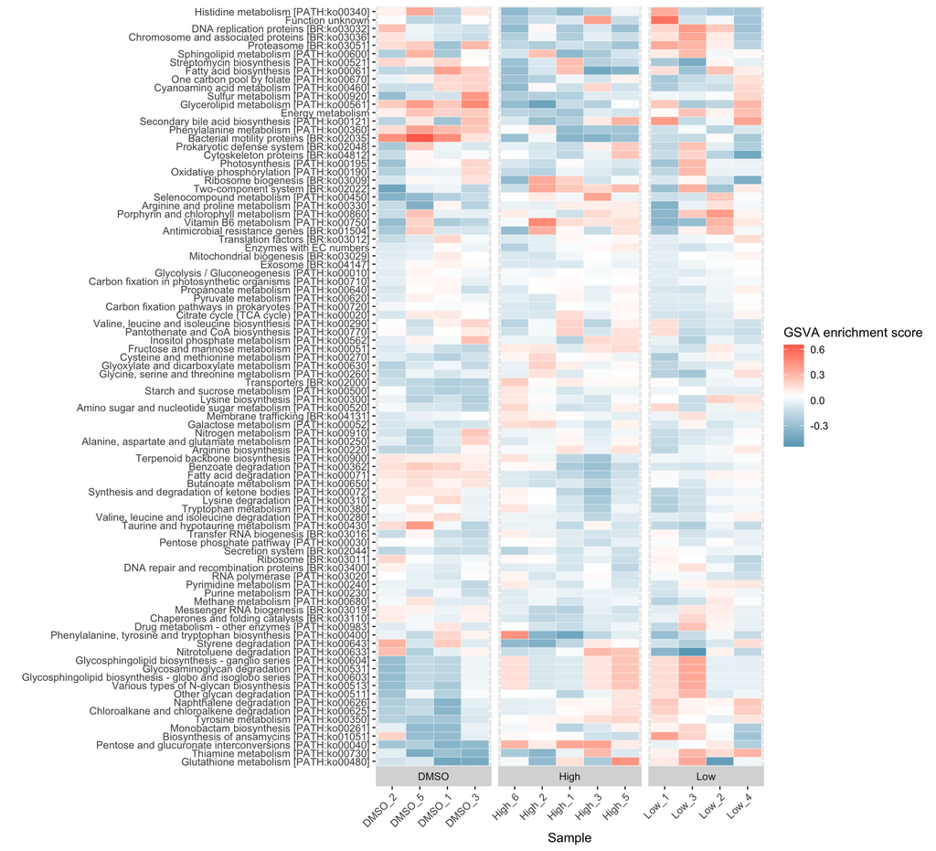